# Predicting the Weather

```r
weather <- read_csv("~/Desktop/Statistics-Notebook/Data/weather.csv")
```

##Background Can the weather of next Monday be predicted? There is data collected from 2011 to 2018 that shows the actual maximum air temperature on every 23th of year.

### Show Data

The data for this analysis comes from the `weather` data set collected from https://www.timeanddate.com/weather/@5605242/historic?month=9&year=2018

#### Weather Data

```r
datatable(weather)
```

|  | Year | Actual_Maximum_Air_Temp |
| --- | --- | --- |
| 1 | 2011 | 82 |
| 2 | 2012 | 77 |
| 3 | 2013 | 64 |
| 4 | 2014 | 79 |
| 5 | 2015 | 82 |
| 6 | 2016 | 52 |
| 7 | 2017 | 54 |
| 8 | 2018 | 64 |

## Analysis

This analysis attempts to model the actual maximum air temperature on the 23th of September using each year where data is collected as the explanatory variable in a linear regression. Code and output of the regression is included below.

$$\underbrace{Y_i}_\text{Actual Maximum Air Temp on 23th} = \overbrace{\beta_0}^\text{y-int} + \overbrace{\beta_1}^\text{slope} \underbrace{X_i}_\text{Year} + \epsilon_i \quad \text{where} \ \epsilon_i \sim N(0, \sigma^2)$$

A test of the hypotheses that the slope of this model is zero will be performed.

$$H_0: \beta_1 = 0$$
$$H_a: \beta_1 \neq 0$$
$$\alpha = 0.05$$

If the slope is zero, then there is not a meaningful relationship between the actual maximum air temperature and year.

###Scatterplot###

```r
weather.lm <- lm(Actual_Maximum_Air_Temp ~ Year, data=weather)
```

From the Scatterplot below, it seems like actual maximum air temperature is getting lower as years pass.

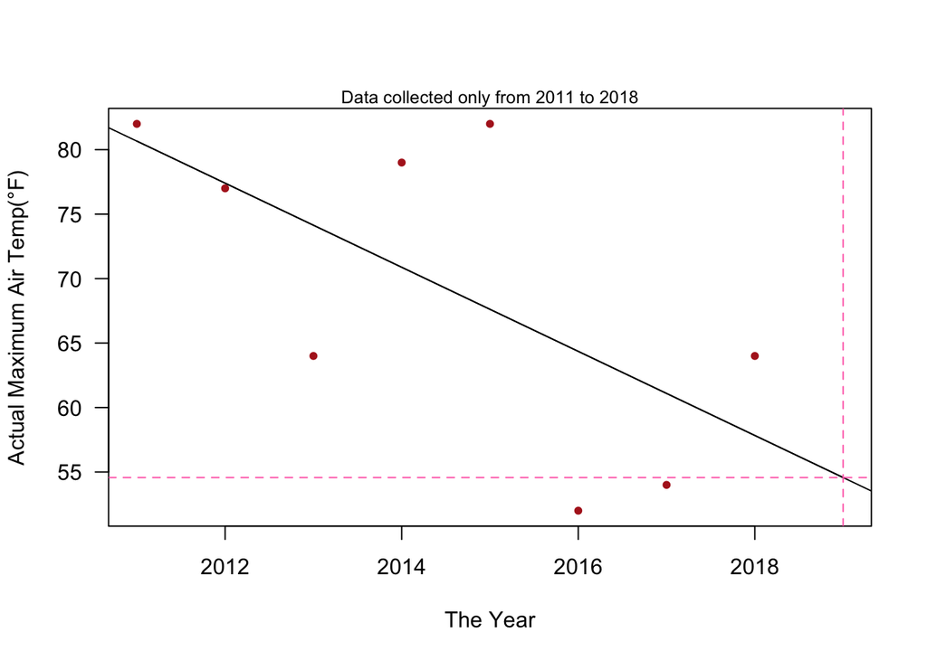

```r
plot(Actual_Maximum_Air_Temp ~ Year, data=weather, pch=20, col="firebrick", xlab="The Year", ylab="Actual Maximum Air Temp(°F)", las=1,xlim=c(2011, 2019))
abline(weather.lm)
mtext(side=3, text="Data collected only from 2011 to 2018", cex=0.8 )
b <- coef(weather.lm)
curve(b[1]+b[2]*x, add=TRUE)
abline(h=predict(weather.lm, newdata = data.frame(Year=2019), interval = "prediction"), lty=2, col="hotpink", v=2019)
```

**Here is the equation of the estimated regression equation.**

$$\underbrace{\hat{Y}_i}_\text{Mean Actual Max Air Temp.} = 6640 -3.262 \underbrace{X_i}_\text{Year}$$
However, this linear regression shows that the slope is not significant(p = 0.08252). Hence the relationship is **not meaningful**.

**Summary of the Regression**

```r
pander(summary(weather.lm))
```

|  | Estimate | Std. Error | t value | Pr(>\|t\|) |
| --- | --- | --- | --- | --- |
| **(Intercept)** | 6640 | 3156 | 2.104 | 0.08005 |
| **Year** | -3.262 | 1.567 | -2.082 | 0.08252 |

Fitting linear model: Actual_Maximum_Air_Temp ~ Year

| Observations | Residual Std. Error | $R^2$ | Adjusted $R^2$ |
| --- | --- | --- | --- |
| 8 | 10.15 | 0.4194 | 0.3226 |

##Interpretation

P-value for the linear regression model is not significant(0.08252). It means that there is not meaningful relationship between the average actual Maximum Air Temp on 23th and year. But all the same, here is my prediction for my model. The mean of actual maximum air temperature on Monday is 54.022; 6640-(3.262*2019) = 54.022. (average actual maximum air temperature from 2011-2018 data is 69.25)

## Appropriateness of the above Regression

A check on the appropriateness of the model shows that it is an appropriate model for linear regression. First graph is Residuals vs Fitted values with non-pattern which means it is linear and the variance of the error terms is constant over all X values. Second graph , Q-Q plot,shows the error terms are normally distributed with E{ϵi}=0. Last graph doesn’t have pattern, that proves the error terms are independent.

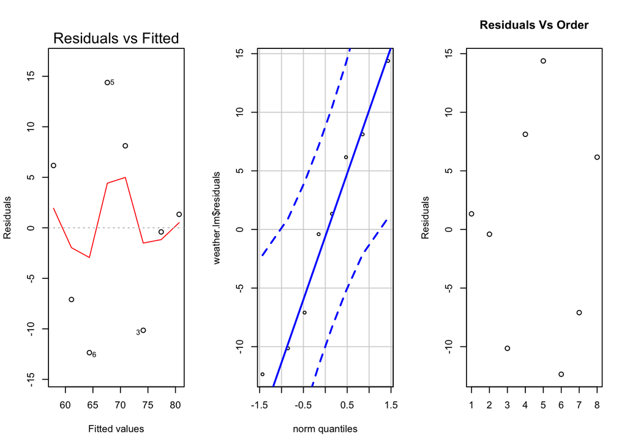

```r
par(mfrow=c(1,3))
plot(weather.lm, which=1)
qqPlot(weather.lm$residuals, id=FALSE)
plot(weather.lm$residuals, main="Residuals Vs Order", xlab = "",ylab = "Residuals")
```